# Tidy Text

Anish Yakkala, Lemar Popal, Brooke Hanna, Michal Golovanevsky

3/7/2019

## What is Tidy Text?

Tidy text is a library made with the [tidy philosophy](https://tidyverse.tidyverse.org/articles/manifesto.html) in mind. The infastructure works with packages like [dplyr](https://dplyr.tidyverse.org/), [broom](https://cran.r-project.org/web/packages/broom/vignettes/broom.html), [tidyr](https://tidyr.tidyverse.org/), and [ggplot2](https://ggplot2.tidyverse.org/reference/).

## Tokenization

Let’s start by reading in the dataset we will be working with throughout this vignette, and loading our main libraries!

The data includes the Reviews, Aggregate Ratings, Subject, Classes, and many more of all the professors on http://polyratings.com.

```r
library(tidyverse)
library(tidytext)
library(lubridate)

polyrating <- read_csv(
  "https://raw.githubusercontent.com/ayakkala1/stat_final/master/vignettes/polyrating.csv"
                      ) %>%
                mutate(date = parse_date_time(date,"%m%y")) %>%
                drop_na()
```

The bread and butter of Text Analysis is tokenizing a corpus. This is to get a dataframe such that each row is a unique token of the corpus. A token can be a single word, combination of words, or even a sentence. We will be focusing right now on a single word, also called unigram, for now.

```r
tokens <- polyrating %>%
  unnest_tokens(word,review) %>%
  select(word,everything())

tokens %>%
  select(word, agg_rating, subject)
```

```
## # A tibble: 6,853,285 x 3
##    word        agg_rating subject
##    <chr>       <chr>      <chr>
##  1 really      3.22/4.00  CHEM
##  2 interesting 3.22/4.00  CHEM
##  3 anytext     3.22/4.00  CHEM
##  4 or          3.22/4.00  CHEM
##  5 1           3.22/4.00  CHEM
##  6 1           3.22/4.00  CHEM
##  7 i           3.22/4.00  CHEM
##  8 had         3.22/4.00  CHEM
##  9 dr          3.22/4.00  CHEM
## 10 abel        3.22/4.00  CHEM
## # … with 6,853,275 more rows
```

Let’s look at the top 5 most common words in the Polyrating Reviews.

```r
tokens %>%
  count(word) %>%
  arrange(desc(n)) %>%
  top_n(5, n)
```

```
## # A tibble: 5 x 2
##   word       n
##   <chr>  <int>
## 1 the   282757
## 2 and   209375
## 3 to    188579
## 4 a     184956
## 5 you   150211
```

Not surpising. These words are often deemed “stop words” in Natural Language Processing, they take up a lot of space and don’t give us very interesting information about the corpus.

To remedy this we will read in a dataset of stop words provided by tidytext and perform an anti-join on our tokens.

(Note: Anti Join simply “return all rows from x where there are not matching values in y, keeping just columns from x.”)

```r
data(stop_words)

tokens <- tokens %>%
  anti_join(stop_words)
```

```r
tokens %>%
  count(word) %>%
  arrange(desc(n)) %>%
  top_n(5, n)
```

```
## # A tibble: 5 x 2
##   word           n
##   <chr>      <int>
## 1 class     109873
## 2 professor  25096
## 3 teacher    22629
## 4 tests      21359
## 5 students   20911
```

As you can see the top 5 most common words have changed!

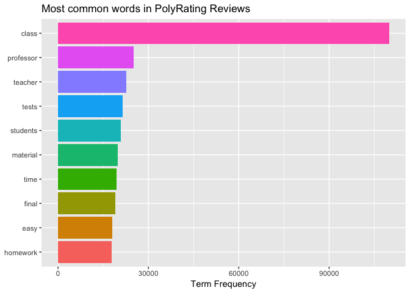

```r
tokens %>%
  count(word, sort = TRUE) %>%
  filter(n > 17500) %>%
  mutate(word = reorder(word, n )) %>%
  ggplot(aes(word, n, fill = word )) + geom_col() +
  xlab(NULL) + coord_flip() + guides(fill=FALSE) + ylab("Term Frequency") +
  ggtitle("Most common words in PolyRating Reviews") + guides(fill=FALSE)
```

You can also customize the stop words by adding your own words to the Stop Words lexicon.

For a lot of the following analysis we will take advantage of customizing the stopwords lexicon. Professor names appear a lot, so we remove that. We also were curious about tokens that involve gender so we remove certain gender words from the stopwords to include them in our analyis.

```r
library(stringr)

names <- tokens %>%
  select(prof_name) %>%
  distinct(prof_name) %>%
  separate(prof_name, c("last", "first"), sep = ",") %>%
  gather() %>%
  select(value) %>%
  mutate(value = str_to_lower(value)) %>%
  pull(value)

custom_stop_words <-stop_words %>%
  filter(!(word %in% c("her","she","he","his"))) %>%
  add_row(word = names,lexicon = "SMART")
```

### Some examples

Here is a cool way to see how word use changes over time.

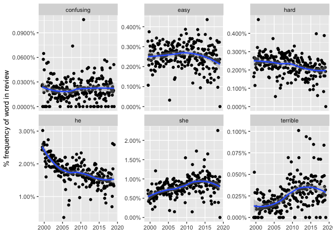

```r
year_counts <- polyrating %>%
  unnest_tokens(word,review) %>%
  select(word,everything()) %>%
  count(date, word) %>%
  complete(date, word, fill = list(n = 0))

year_totals <- year_counts %>%
  group_by(date) %>%
  summarize(year_total = sum(n))

year_counts %>%
  left_join(year_totals, by = "date") %>%
  filter(word %in% c("terrible", "he", "confusing", "she", "easy", "hard")) %>%
  ggplot(aes(date, n / year_total)) +
  geom_point() +
  geom_smooth() +
  facet_wrap(~ word, scales = "free_y") +
  scale_y_continuous(labels = scales::percent_format()) +
  ylab("% frequency of word in review") +
  xlab(element_blank())
```

Let’s end by comparing the Term Frequencies between Chemistry and Statistics to see which words are used a lot more in the Chemistry Reviews compared to the Statistics reviews.

To start let’s set up a dataframe to make term frequencies for each subject.

```r
review_words <- tokens %>%
  count(subject, word, sort = TRUE) %>%
  ungroup()

total_words <- review_words %>%
  group_by(subject) %>%
  summarize(total = sum(n))

review_words <- left_join(review_words, total_words)

review_words %>%
  mutate(freq = n/total)
```

```
## # A tibble: 242,452 x 5
##    subject word         n  total   freq
##    <chr>   <chr>    <int>  <int>  <dbl>
##  1 ENGL    class    10706 174657 0.0613
##  2 BUS     class     9307 165068 0.0564
##  3 MATH    class     9154 213750 0.0428
##  4 COMS    class     6559 116944 0.0561
##  5 PHYS    class     6487 144097 0.0450
##  6 CSC     class     5010 124839 0.0401
##  7 MATH    homework  4653 213750 0.0218
##  8 CHEM    class     4574 117749 0.0388
##  9 ECON    class     4398  74953 0.0587
## 10 BIO     class     4061  86433 0.0470
## # … with 242,442 more rows
```

Now to visualizing the differences.

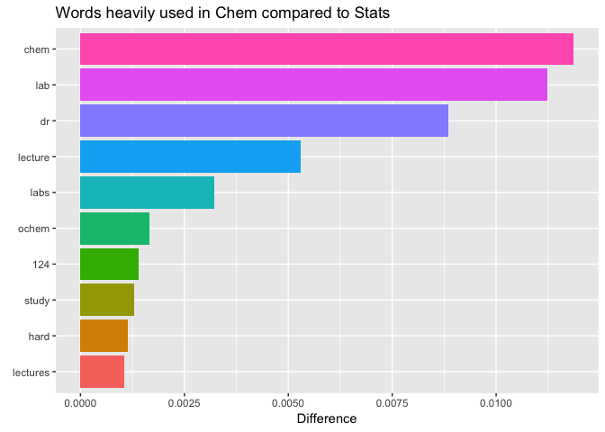

```r
review_words %>%
  filter(subject %in% c("STAT","CHEM")) %>%
  mutate(freq = n/total) %>%
  unite(freq_n,c(freq,n),sep="::") %>%
  select(subject,freq_n,word) %>%
    spread(subject,freq_n) %>%
    separate(CHEM,c("CHEM_FREQ","CHEM_N"),sep="::") %>%
    separate(STAT,c("STAT_FREQ","STAT_N"),sep="::") %>%
    drop_na() %>%
    mutate(CHEM_FREQ = as.numeric(CHEM_FREQ),
           STAT_FREQ = as.numeric(STAT_FREQ)) %>%
    mutate(diff = CHEM_FREQ - STAT_FREQ) %>%
    top_n(10, diff) %>%
    mutate(word = fct_reorder(word, diff)) %>%
    ggplot(aes(word, diff,fill = word)) + geom_col() +
      coord_flip() + xlab(element_blank()) + ylab("Difference") + guides(fill=FALSE) +
      ggtitle("Words heavily used in Chem compared to Stats")
```

Not surpising that “chem” is used a lot more in Chemistry reviews. However it is interesting that “dr” is used a lot more in Chemistry reviews versus Statis Reviews.

## Sentiment Analysis

PolyRating can become quite a heated place for students. This is prime data for doing a common practice in NLP called “Sentiment Analysis”. Sentiment Analysis is the process of identifying and categorizing the attitudes and opinions expressed in a corpus.

Tidy Text gives us 3 datasets to conduct our own Sentiment Analysis. Each helps us tell things about the sentiment of a text, but each in very different ways.

Let’s take a look.

### AFINN

```r
set.seed(2017)

get_sentiments("afinn") %>%
  sample_n(10)
```

```
## # A tibble: 10 x 2
##    word         score
##    <chr>        <int>
##  1 unbelievable    -1
##  2 insulted        -2
##  3 haunt           -1
##  4 dismal          -2
##  5 retained        -1
##  6 revered          2
##  7 agreed           1
##  8 genial           3
##  9 healthy          2
## 10 disappears      -1
```

AFINN scores unigrams between $(-5,5)$. As you can guess, negative means a negative sentiment, positive means a positive sentiment, and zero is neutral. This is useful if you want work with sentiment as a quantitative variable. Such as using it in a scatterplot or regressor.

### BING

```r
set.seed(2010)

get_sentiments("bing") %>%
  sample_n(10)
```

```
## # A tibble: 10 x 2
##    word         sentiment
##    <chr>        <chr>
##  1 enfeeble     negative
##  2 ire          negative
##  3 infernal     negative
##  4 distraughtly negative
##  5 stellarly    positive
##  6 unwarranted  negative
##  7 marvelled    positive
##  8 apocalypse   negative
##  9 harmed       negative
## 10 alluringly   positive
```

BING scores unigrams as “positive” or “negative”. This is useful if you want sentiment as a Binarized variable. This makes it easy to do analysis that involves Counts & Proportions.

### NRC

```r
set.seed(2010)

get_sentiments("nrc") %>%
  sample_n(10)
```

```
## # A tibble: 10 x 2
##    word       sentiment
##    <chr>      <chr>
##  1 dreadfully fear
##  2 journey    joy
##  3 injection  fear
##  4 diligence  positive
##  5 spiteful   anger
##  6 urgent     negative
##  7 merriment  positive
##  8 annulment  sadness
##  9 guillotine fear
## 10 alienate   anger
```

NRC places unigrams into various classes of which they may fall either into a positive or negative category. This may be useful if you want to classify your corpus in a more general way.

### Application

Let’s use NRC to explore the PolyRating data. We will begin by extracting the “anger” words from the NRC Lexicon.

```r
nrc_anger <- get_sentiments("nrc") %>%
  filter(sentiment == "anger")
```

Now let’s do an inner join to see the words that were both in the “anger” dictionary and PolyRating Reviews, and then see their counts.

```r
tokens %>%
  inner_join(nrc_anger) %>%
  count(word, sort = TRUE) %>%
  top_n(5, n)
```

```
## # A tibble: 5 x 2
##   word         n
##   <chr>    <int>
## 1 bad       8061
## 2 shit      2803
## 3 horrible  1878
## 4 terrible  1717
## 5 hate      1371
```

This time let’s use the Bing lexicon to see how Sentiment in various [COSAM](http://www.cosam.calpoly.edu/) Departments change over time.

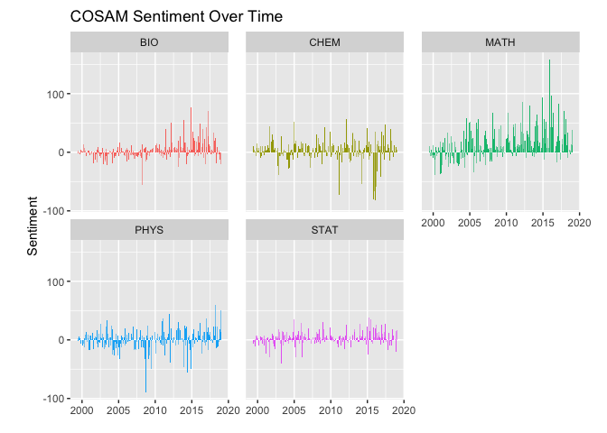

```r
tokens %>%
  inner_join(get_sentiments("bing")) %>%
    filter(subject %in% c("MATH", "STAT", "CHEM", "PHYS", "BIO"," LS")) %>%
    count(date, subject, sentiment) %>%
      spread(sentiment, n, fill = 0) %>%
      mutate(sentiment = positive - negative) %>%
      ggplot(aes(date, sentiment,fill = subject)) + geom_col(show.legend = FALSE) +
             facet_wrap(~subject) + ggtitle("COSAM Sentiment Over Time") +
             theme(panel.spacing.x = unit(1, "lines"),
                   plot.margin = margin(.3, .8, .3, .8, "cm")) +
             xlab(element_blank()) + ylab("Sentiment")
```

Furthermore, using Bing again, let’s see what words contributed most to the Postive Sentiment and to the Negative Sentiment.

Let’s first get our token counts with the Bing lexicon joined.

```r
bing_word_counts <- tokens %>%
  inner_join(get_sentiments("bing")) %>%
  count(word, sentiment, sort = TRUE) %>%
  ungroup()

bing_word_counts
```

```
## # A tibble: 3,965 x 3
##    word      sentiment     n
##    <chr>     <chr>     <int>
##  1 easy      positive  18087
##  2 hard      negative  15805
##  3 pretty    positive  12357
##  4 recommend positive   9490
##  5 nice      positive   8151
##  6 bad       negative   8061
##  7 difficult negative   7774
##  8 helpful   positive   7113
##  9 boring    negative   5460
## 10 fair      positive   5313
## # … with 3,955 more rows
```

Let’s see the side by side comparison.

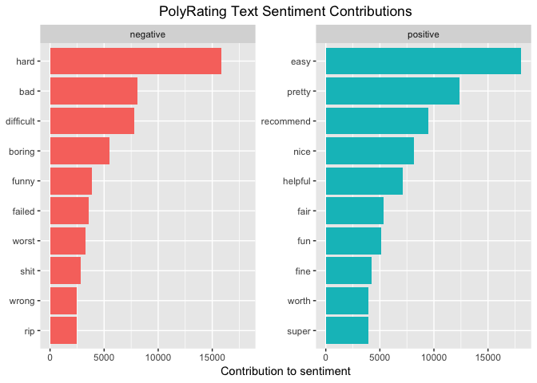

```r
bing_word_counts %>%
  group_by(sentiment) %>%
  top_n(10) %>%
  ungroup() %>%
  mutate(word = reorder(word, n)) %>%
  ggplot(aes(word, n, fill = sentiment)) + geom_col(show.legend = FALSE) +
             facet_wrap(~sentiment, scales = "free_y") +
             labs(y = "Contribution to sentiment",
                  x = NULL) +
             coord_flip() +
             ggtitle("PolyRating Text Sentiment Contributions")  +
             theme(plot.title = element_text(hjust = 0.5))
```

Finally, let’s see which Subjects have the most Negative and Positive Sentiments using Bing.

```r
bingnegative <- get_sentiments("bing") %>%
  filter(sentiment == "negative")

bingpositive <- get_sentiments("bing") %>%
  filter(sentiment == "positive")

wordcounts <- tokens %>%
  group_by(subject) %>%
  summarize(words = n())
```

Negative :

```r
tokens %>%
  semi_join(bingnegative) %>%
  group_by(subject) %>%
  summarize(negativewords = n()) %>%
  left_join(wordcounts, by = c("subject")) %>%
  mutate(ratio = negativewords/words) %>%
  ungroup() %>%
  arrange(desc(ratio)) %>%
  top_n(5, ratio)
```

```
## # A tibble: 5 x 4
##   subject negativewords  words  ratio
##   <chr>           <int>  <int>  <dbl>
## 1 GBA               165   1362 0.121
## 2 HUM               202   1884 0.107
## 3 CSC             12416 124839 0.0995
## 4 PHIL             9503  96469 0.0985
## 5 MSC                46    480 0.0958
```

Positive :

```r
tokens %>%
  semi_join(bingpositive) %>%
  group_by(subject) %>%
  summarize(positivewords = n()) %>%
  left_join(wordcounts, by = c("subject")) %>%
  mutate(ratio = positivewords/words) %>%
  ungroup() %>%
  arrange(desc(ratio)) %>%
  top_n(5, ratio)
```

```
## # A tibble: 5 x 4
##   subject positivewords words ratio
##   <chr>           <int> <int> <dbl>
## 1 DSCI              435  3672 0.118
## 2 SCI               470  4345 0.108
## 3 WS                187  1740 0.107
## 4 PSY              5527 52101 0.106
## 5 FSN              1680 16276 0.103
```

## TF-IDF

Let’s say we want to find what words are the most important to reviews for each Subject. One guess would be that using the words that are the most frequent in the reviews for the Subject would be the most representative. While it can be true in some cases, recall when we first looked at the most frequent words in the PolyRating Reviews. Words like “the” and “a” were the most frequent, and while it is true they are also just simple conjuctions. We need a new metric that can reveal to us the most important words for each group we are interested in.

Before we reveal it let’s take a look at how the Term Frequencies are distributed between COSAM Subjects.

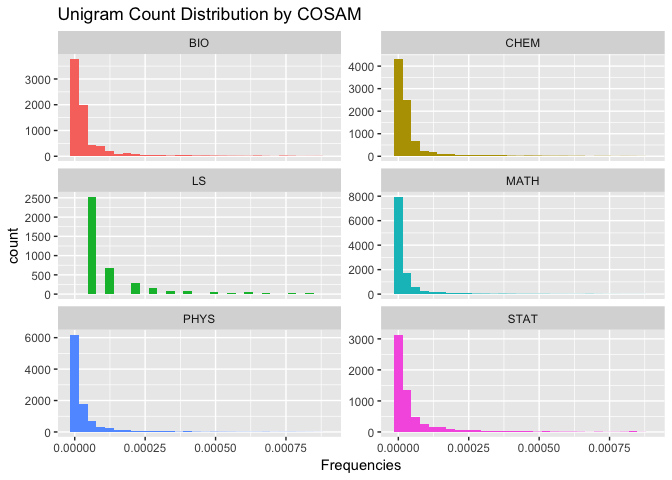

```r
review_words <- tokens %>%
  count(subject, word, sort = TRUE) %>%
  ungroup()

total_words <- review_words %>%
  group_by(subject) %>%
  summarize(total = sum(n))

review_words <- left_join(review_words, total_words)

review_words %>%
  filter(subject %in% c("MATH","STAT","CHEM","PHYS","BIO","LS")) %>%
  ggplot(aes(n/total, fill = subject)) +
  geom_histogram(show.legend = FALSE) +
  xlim(NA, 0.0009) +
  facet_wrap(~subject, ncol = 2, scales = "free_y") +
  ggtitle("Unigram Count Distribution by COSAM") +
  xlab("Frequencies")
```

They all look to be distributed very similarily, with a heavy right tail.

This brings us to the idea of TF-IDF (Term Frequency - Inverse Document Frequence). Seeing those heavy right tails indicates that there are some rare words that define each Subject. Those words can be important words that define a document in a corpus. To remedy this we use TF-IDF.

For a term $i$ in document $j$.

$$w_{i,j} = tf_{i,j} * log(\frac{N}{df_{i}})$$

$tf_{i,j} =$ number of occurrenes of $i$ in $j$.

$df_{i} =$ number of documents containing $i$.

$N =$ total number of documents

Tidytext makes it easy to get the TF-IDF for our tokens.

```r
review_tf_words <- review_words %>%
  bind_tf_idf(word, subject, n)

review_tf_words %>%
  select(word, n, tf, idf, tf_idf)
```

```
## # A tibble: 242,452 x 5
##    word         n     tf    idf   tf_idf
##    <chr>    <int>  <dbl>  <dbl>    <dbl>
##  1 class    10706 0.0613 0      0
##  2 class     9307 0.0564 0      0
##  3 class     9154 0.0428 0      0
##  4 class     6559 0.0561 0      0
##  5 class     6487 0.0450 0      0
##  6 class     5010 0.0401 0      0
##  7 homework  4653 0.0218 0.0183 0.000399
##  8 class     4574 0.0388 0      0
##  9 class     4398 0.0587 0      0
## 10 class     4061 0.0470 0      0
## # … with 242,442 more rows
```

As you can see very common words with a high term frequency are given a very low tf-idf score.

Let’s now see what the most important words are for the COSAM subjects using TF-IDF!

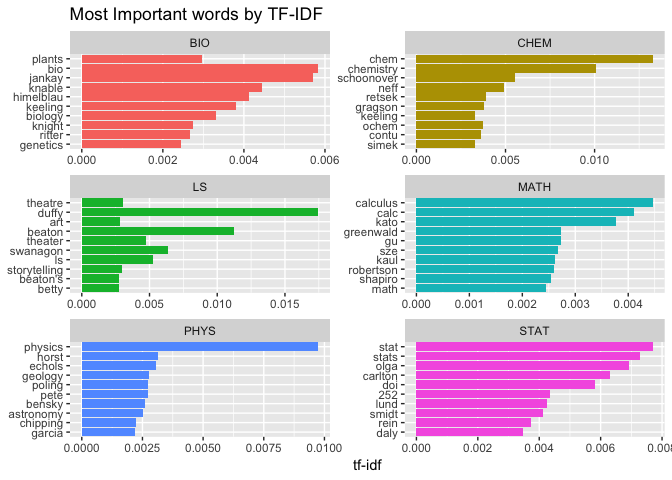

```r
review_tf_words %>%
  arrange(desc(tf_idf)) %>%
  mutate(word = factor(word, levels = rev(unique(word)))) %>%
  filter(subject %in% c("MATH","STAT","CHEM","PHYS","BIO","LS")) %>%
  group_by(subject) %>%
  top_n(10) %>%
  ungroup %>%
  ggplot(aes(word, tf_idf, fill = subject)) +
    geom_col(show.legend = FALSE) +
    labs(x = NULL, y = "tf-idf") +
    facet_wrap(~subject, ncol = 2, scales = "free") +
    coord_flip() + ggtitle("Most Important words by TF-IDF")  +
    scale_x_discrete(expand = c(0,0.5))
```

## N-grams

So far we have been tokenizing the corpus by individual words. However we can tokenize by any amount of words we want. In general we tokenize by n-grams. The case of one is called a unigram, two is bigram, three is trigram, and so on.

Tidy Text makes this easy for us to do.

```r
poly_bigrams <- polyrating %>%
  unnest_tokens(bigram, review, token ="ngrams", n = 2) %>%
  select(bigram, everything())

poly_bigrams %>%
  select(bigram, agg_rating, subject) %>%
  tail()
```

```
## # A tibble: 6 x 3
##   bigram     agg_rating subject
##   <chr>      <chr>      <chr>
## 1 her for    3.01/4.00  ENGL
## 2 for any    3.01/4.00  ENGL
## 3 any class  3.01/4.00  ENGL
## 4 class you  3.01/4.00  ENGL
## 5 you can    3.01/4.00  ENGL
## 6 can period 3.01/4.00  ENGL
```

Similarily to what we did with unigrams let’s look at the term frequencies of the PolyRating bigrams.

```r
poly_bigrams %>%
  count(bigram, sort = TRUE)
```

```
## # A tibble: 797,705 x 2
##    bigram         n
##    <chr>      <int>
##  1 if you     38460
##  2 of the     28369
##  3 the class  26118
##  4 is a       23456
##  5 this class 23038
##  6 he is      20405
##  7 in the     19871
##  8 on the     17802
##  9 a lot      14958
## 10 for the    14000
## # … with 797,695 more rows
```

This suffers the same issues as using the term frequencies of unigrams, the existance of simple conjuctions that don’t tell us much.

Now let’s remove the stop words from the bigrams.

```r
bigrams_separated <- poly_bigrams %>%
  separate(bigram, c("word1", "word2"), sep = " ")

bigrams_filtered <- bigrams_separated %>%
  filter(!word1 %in% custom_stop_words$word) %>%
  filter(!word2 %in% custom_stop_words$word)

bigram_counts <- bigrams_filtered %>%
  count(word1, word2, sort = TRUE)

bigrams_united <- bigrams_filtered %>%
  unite(bigram, word1, word2, sep = " ")

bigrams_united
```

```
## # A tibble: 765,220 x 12
##    bigram Evaluations agg_rating material_clearly prof_name
##    <chr>  <chr>       <chr>                 <dbl> <chr>
##  1 livin… 1           0.00/4.00                 0 Ramirez,…
##  2 title… 1           0.00/4.00                 0 Ramirez,…
##  3 publi… 1           0.00/4.00                 0 Ramirez,…
##  4 grant… 1           0.00/4.00                 0 Ramirez,…
##  5 commu… 1           0.00/4.00                 0 Ramirez,…
##  6 encom… 1           0.00/4.00                 0 Ramirez,…
##  7 hell … 1           0.00/4.00                 0 Ramirez,…
##  8 she w… 1           0.00/4.00                 0 Ramirez,…
##  9 worst… 1           0.00/4.00                 0 Ramirez,…
## 10 diffi… 1           0.00/4.00                 0 Ramirez,…
## # … with 765,210 more rows, and 7 more variables:
## #   recognize_student_diff <dbl>, subject <chr>, class <chr>,
## #   standing <chr>, grade <chr>, reason <chr>, date <dttm>
```

We can do this for trigrams as well.

```r
trigrams_filtered <- polyrating %>%
  unnest_tokens(trigram, review, token = "ngrams", n = 3) %>%
  separate(trigram, c("word1", "word2", "word3"), sep = " ") %>%
  filter(!word1 %in%  custom_stop_words$word,
         !word2 %in% custom_stop_words$word,
         !word3 %in% custom_stop_words$word) %>%
  select(word1,word2,word3,everything())

trigrams_filtered %>%
  select(word1, word2, word3, prof_name)
```

```
## # A tibble: 241,626 x 4
##    word1       word2      word3       prof_name
##    <chr>       <chr>      <chr>       <chr>
##  1 titled      public     health      Ramirez, Sarah
##  2 hell        she        writes      Ramirez, Sarah
##  3 context     whatsoever she         Ramirez, Sarah
##  4 whatsoever  she        flies       Ramirez, Sarah
##  5 poorly      written    tests       Ramirez, Sarah
##  6 assignments she        teaches     Ramirez, Sarah
##  7 bulky       readings   assignments Ramirez, Sarah
##  8 excellent   fsn        department  Ramirez, Sarah
##  9 blah        blah       blah        Potthast, Fredrick
## 10 blah        blah       he          Potthast, Fredrick
## # … with 241,616 more rows
```

We can even use TF-IDF on n-grams.

```r
bigram_tf_idf <- bigrams_united %>%
  count(subject, bigram) %>%
  bind_tf_idf(bigram, subject, n) %>%
  arrange(desc(tf_idf))

bigram_tf_idf
```

```
## # A tibble: 398,270 x 6
##    subject bigram                    n     tf   idf tf_idf
##    <chr>   <chr>                 <int>  <dbl> <dbl>  <dbl>
##  1 PHIL    policies homework      2001 0.0644  2.62 0.169
##  2 PHIL    teacher's grading      2001 0.0644  2.22 0.143
##  3 PHIL    load tests             2000 0.0644  2.22 0.143
##  4 MSC     5'4 36                    2 0.0117  4.01 0.0469
##  5 MSC     army values               2 0.0117  4.01 0.0469
##  6 MSC     famous shakespearean      2 0.0117  4.01 0.0469
##  7 MSC     fierce sfc                2 0.0117  4.01 0.0469
##  8 MSC     questions.his tests       2 0.0117  4.01 0.0469
##  9 MSC     shakespearean quote       2 0.0117  4.01 0.0469
## 10 MSC     student questions.his     2 0.0117  4.01 0.0469
## # … with 398,260 more rows
```

..and then see the top tf-idf bigrams for each COSAM section.

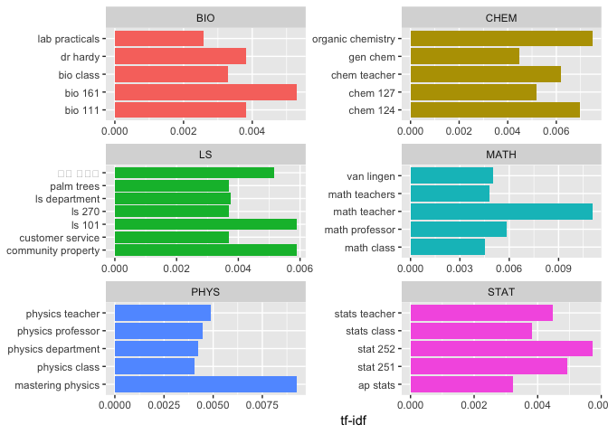

```r
bigram_tf_idf %>%
  filter(subject %in% c("MATH","STAT","CHEM","PHYS","BIO","LS")) %>%
  group_by(subject) %>%
  top_n(5) %>%
  mutate(bigram = fct_reorder(bigram, n)) %>%
  ungroup() %>%
  ggplot(aes(bigram, tf_idf, fill = subject)) +
    geom_col(show.legend = FALSE) +
    labs(x = NULL, y = "tf-idf") +
    facet_wrap(~subject, ncol = 2, scales = "free") +
    coord_flip()
```

### Negation

Let’s examine negation using AFINN and bigrams.

Let’s get AFINN.

```r
AFINN <- get_sentiments("afinn")

AFINN
```

```
## # A tibble: 2,476 x 2
##    word       score
##    <chr>      <int>
##  1 abandon       -2
##  2 abandoned     -2
##  3 abandons      -2
##  4 abducted      -2
##  5 abduction     -2
##  6 abductions    -2
##  7 abhor         -3
##  8 abhorred      -3
##  9 abhorrent     -3
## 10 abhors        -3
## # … with 2,466 more rows
```

Now let’s get the “not” bigrams.

```r
not_words <- bigrams_separated %>%
  filter(word1 == "not") %>%
  inner_join(AFINN, by = c(word2 = "word")) %>%
  count(word2, score, sort = TRUE) %>%
  ungroup()

not_words
```

```
## # A tibble: 398 x 3
##    word2     score     n
##    <chr>     <int> <int>
##  1 recommend     2   737
##  2 hard         -1   580
##  3 like          2   530
##  4 easy          1   426
##  5 bad          -3   407
##  6 worth         2   319
##  7 difficult    -1   275
##  8 help          2   243
##  9 helpful       2   218
## 10 good          3   202
## # … with 388 more rows
```

We can also now visualize the sentiment of these bigrams, by taking the opposite of the word following “not” and using the opposite sign.

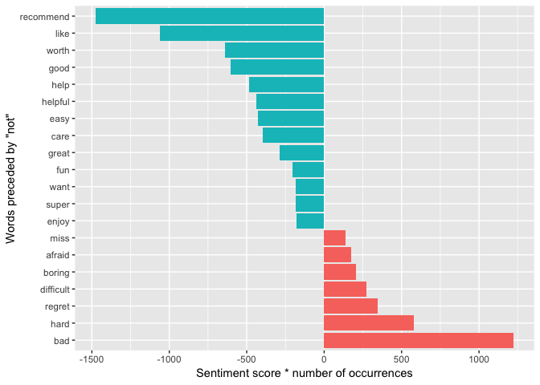

```r
not_words %>%
  mutate(contribution = n * score) %>%
  arrange(desc(abs(contribution))) %>%
  head(20) %>%
  mutate(word2 = reorder(word2, contribution)) %>%
  ggplot(aes(word2, -n * score, fill = n * score > 0)) +
  geom_col(show.legend = FALSE) +
  xlab("Words preceded by \"not\"") +
  ylab("Sentiment score * number of occurrences") +
  coord_flip()
```

## Acknowledements

Thank you to the creators of Tidy Text for making a great package!